# External drivers (jumeau)

# External drivers (jumeau)

This file is part of the **jumeau** version of the project, in which we test external drivers for the block models. It complements `02_dta_cleaning.qmd`: it builds the quarterly external drivers and saves them in a separate file, `DTA_CLEAN/drivers_jumeau.csv`, without modifying any file written by `02_dta_cleaning.qmd`.

Drivers included so far:

1. **Mortgage rate** (for rents): the rate to which rents are legally tied.
2. **SNB policy rate** (for domestic goods excl. rents): the stance of monetary policy.

```r
source(here::here("Scripts", "01_load_data.R"))
```

```
here() starts at /Users/yanik/Forecasting
```

```
01_load_data.R done: cpi_index, cpi_weights, gdp, fx, policy_rates, brent, hicp_ea, unemployed, reference_rate, variable_mortgage
```

```r
clean_dir <- here::here("DTA_CLEAN")
dir.create(clean_dir, showWarnings = FALSE)
```

# 1. Mortgage rate for rents

Swiss rents are adjusted when the mortgage rate they are tied to changes: under the tenancy ordinance (Art. 13 VMWG), a rise of 0.25 pp allows a rent increase of up to 3 % when the rate is below 5 %. The benchmark rate changed in September 2008:

- **until September 2008**: the variable mortgage rate of the leading local bank (usually the cantonal bank). We use the SNB average variable mortgage rate (cube `zikrepro`), loaded in section 10 of `01_load_data.R`;
- **from September 2008**: the federal mortgage reference rate (BWO), loaded in section 9 of `01_load_data.R`.

We splice the two series: the variable mortgage rate up to 2008Q3, the reference rate from 2008Q4. Both play the same legal role, and rates were below 5 % on both sides of the splice, so the same 3 % rule applies.

```r
# Reference rate: one value per announcement (valid_from). Monthly series =
# the rate valid on the first day of each month, from October 2008 (first
# full month after its introduction in September 2008).
reference_monthly <- tibble(date = seq(as.Date("2008-10-01"), max(variable_mortgage$date),
                                       by = "month")) %>%
  mutate(reference_rate = map_dbl(date, \(d)
           tail(reference_rate$reference_rate[reference_rate$valid_from <= d], 1)))

# Quarterly averages of both series (complete quarters only)
to_quarterly <- function(data, col) {
  data %>%
    group_by(date = floor_date(date, "quarter")) %>%
    summarise(value = mean(.data[[col]]), n_months = n(), .groups = "drop") %>%
    filter(n_months == 3) %>%
    select(date, value)
}
variable_q  <- to_quarterly(variable_mortgage, "variable_mortgage_rate")
reference_q <- to_quarterly(reference_monthly, "reference_rate")

# Spliced mortgage rate: variable rate up to 2008Q3, reference rate from 2008Q4
mortgage_rate <- variable_q %>%
  rename(variable_rate = value) %>%
  left_join(reference_q %>% rename(reference_rate = value), by = "date") %>%
  mutate(mortgage_rate = if_else(date < as.Date("2008-10-01"), variable_rate, reference_rate))

# Check: no gaps, and the two series around the splice
stopifnot(!anyNA(mortgage_rate$mortgage_rate),
          all(diff(mortgage_rate$date) %in% 89:92))
mortgage_rate %>%
  filter(date >= as.Date("2008-01-01"), date <= as.Date("2009-07-01")) %>%
  as.data.frame()
```

```
        date variable_rate reference_rate mortgage_rate
1 2008-01-01      3.323333             NA      3.323333
2 2008-04-01      3.426667             NA      3.426667
3 2008-07-01      3.470000             NA      3.470000
4 2008-10-01      3.150000           3.50      3.500000
5 2009-01-01      2.776667           3.50      3.500000
6 2009-04-01      2.746667           3.50      3.500000
7 2009-07-01      2.740000           3.25      3.250000
```

```r
range(mortgage_rate$date)
```

```
[1] "1980-01-01" "2026-07-01"
```

At the splice the two rates are close (about 3.3–3.5 %), so the spliced series has no artificial jump. The models use the quarterly **change** in the rate, which is not affected by the small level difference.

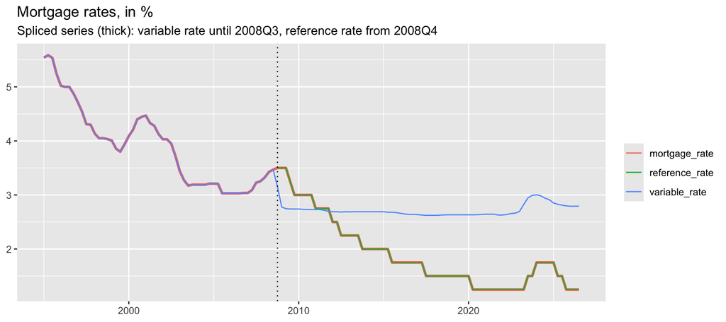

```r
mortgage_rate %>%
  filter(date >= as.Date("1995-01-01")) %>%
  pivot_longer(c(variable_rate, reference_rate, mortgage_rate)) %>%
  ggplot(aes(date, value, colour = name, linewidth = name == "mortgage_rate")) +
  geom_line() +
  geom_vline(xintercept = as.Date("2008-10-01"), linetype = "dotted") +
  scale_linewidth_manual(values = c(0.5, 1.1), guide = "none") +
  labs(title = "Mortgage rates, in %", subtitle = "Spliced series (thick): variable rate until 2008Q3, reference rate from 2008Q4",
       x = NULL, y = NULL, colour = NULL)
```

After 2008 the variable mortgage rate stays around 2.6–2.8 % while the reference rate falls to 1.25 %: variable mortgages became a niche product and no longer reflect the cost of mortgages, which is why the reference rate is used from 2008Q4.

# 2. SNB policy rate for domestic goods

The SNB sets its policy rate according to its inflation outlook: it raises the rate when it expects price pressure and cuts it when it expects inflation to fall. The rate therefore carries information about upcoming domestic inflation. We use the Swiss policy rate built in `02_dta_cleaning.qmd`: the midpoint of the target range for the 3-month CHF Libor until May 2019, the SNB policy rate since June 2019.

```r
# SNB policy rate, monthly, end of month, in % (02_dta_cleaning.qmd)
policy_m <- read_csv(file.path(clean_dir, "policy_rate_clean.csv"), show_col_types = FALSE)

# Quarterly averages. The series ends in August 2026, so 2026Q3 is the
# average of July and August.
policy_rate <- policy_m %>%
  group_by(date = floor_date(date, "quarter")) %>%
  summarise(policy_rate = mean(policy_rate), n_months = n(), .groups = "drop")
tail(policy_rate, 3)
```

```
# A tibble: 3 x 3
  date       policy_rate n_months
  <date>           <dbl>    <int>
1 2026-01-01           0        3
2 2026-04-01           0        3
3 2026-07-01           0        2
```

```r
# The series starts in January 2000: the SNB introduced its target range on
# 10 December 1999 (1.25-2.25 %, midpoint 1.75 %). The models use lagged
# changes of the rate, so the first quarters of the sample need values for
# 1999. We hold the December 1999 midpoint (1.75 %) for 1999Q1-1999Q4: the
# lagged changes in 1999 are then zero. This only affects the first quarters
# of the estimation sample.
policy_rate <- bind_rows(
  tibble(date = seq(as.Date("1999-01-01"), as.Date("1999-10-01"), by = "quarter"),
         policy_rate = 1.75),
  policy_rate %>% select(date, policy_rate))
head(policy_rate, 6)
```

```
# A tibble: 6 x 2
  date       policy_rate
  <date>           <dbl>
1 1999-01-01        1.75
2 1999-04-01        1.75
3 1999-07-01        1.75
4 1999-10-01        1.75
5 2000-01-01        2.33
6 2000-04-01        3.17
```

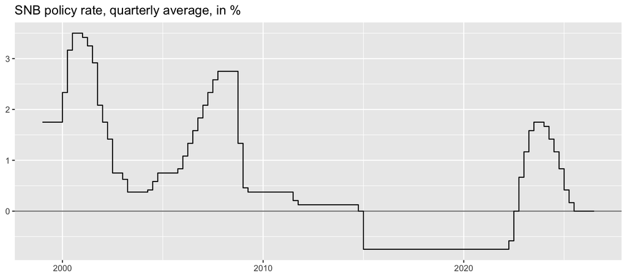

```r
policy_rate %>%
  ggplot(aes(date, policy_rate)) +
  geom_hline(yintercept = 0, colour = "grey50") +
  geom_step() +
  labs(title = "SNB policy rate, quarterly average, in %", x = NULL, y = NULL)
```

The rate shows the main phases of Swiss monetary policy: cuts after 2001 and 2008, negative rates from 2015 to 2022, the rapid increase to 1.75 % in 2022–2023, and the cuts back to 0 % since 2024.

# 3. Save

```r
drivers_jumeau <- mortgage_rate %>%
  select(date, mortgage_rate) %>%
  full_join(policy_rate, by = "date") %>%
  arrange(date)

write_csv(drivers_jumeau, file.path(clean_dir, "drivers_jumeau.csv"))
tail(drivers_jumeau)
```

```
# A tibble: 6 x 3
  date       mortgage_rate policy_rate
  <date>             <dbl>       <dbl>
1 2025-04-01          1.5        0.167
2 2025-07-01          1.5        0
3 2025-10-01          1.25       0
4 2026-01-01          1.25       0
5 2026-04-01          1.25       0
6 2026-07-01          1.25       0
```